# Risk Factor Analysis

## Outcome Variable

**Outcome Variable:** ever_swasted

## Predictor Variables

**Intervention Variable:** nrooms

**Adjustment Set:**

unadjusted

## Stratifying Variables

The analysis was stratified on these variable(s):

- agecat
- studyid
- country

## Data Summary

| agecat | studyid | country | nrooms | ever_swasted | n_cell | n |
| --- | --- | --- | --- | --- | --- | --- |
| 0-24 months | CMC-V-BCS-2002 | INDIA | 4+ | 0 | 11 | 373 |
| 0-24 months | CMC-V-BCS-2002 | INDIA | 4+ | 1 | 3 | 373 |
| 0-24 months | CMC-V-BCS-2002 | INDIA | 1 | 0 | 145 | 373 |
| 0-24 months | CMC-V-BCS-2002 | INDIA | 1 | 1 | 57 | 373 |
| 0-24 months | CMC-V-BCS-2002 | INDIA | 2 | 0 | 83 | 373 |
| 0-24 months | CMC-V-BCS-2002 | INDIA | 2 | 1 | 23 | 373 |
| 0-24 months | CMC-V-BCS-2002 | INDIA | 3 | 0 | 42 | 373 |
| 0-24 months | CMC-V-BCS-2002 | INDIA | 3 | 1 | 9 | 373 |
| 0-24 months | COHORTS | INDIA | 4+ | 0 | 100 | 5366 |
| 0-24 months | COHORTS | INDIA | 4+ | 1 | 6 | 5366 |
| 0-24 months | COHORTS | INDIA | 1 | 0 | 3106 | 5366 |
| 0-24 months | COHORTS | INDIA | 1 | 1 | 405 | 5366 |
| 0-24 months | COHORTS | INDIA | 2 | 0 | 1423 | 5366 |
| 0-24 months | COHORTS | INDIA | 2 | 1 | 131 | 5366 |
| 0-24 months | COHORTS | INDIA | 3 | 0 | 184 | 5366 |
| 0-24 months | COHORTS | INDIA | 3 | 1 | 11 | 5366 |
| 0-24 months | CONTENT | PERU | 4+ | 0 | 77 | 215 |
| 0-24 months | CONTENT | PERU | 4+ | 1 | 1 | 215 |
| 0-24 months | CONTENT | PERU | 1 | 0 | 44 | 215 |
| 0-24 months | CONTENT | PERU | 1 | 1 | 0 | 215 |
| 0-24 months | CONTENT | PERU | 2 | 0 | 54 | 215 |
| 0-24 months | CONTENT | PERU | 2 | 1 | 0 | 215 |
| 0-24 months | CONTENT | PERU | 3 | 0 | 39 | 215 |
| 0-24 months | CONTENT | PERU | 3 | 1 | 0 | 215 |
| 0-24 months | GMS-Nepal | NEPAL | 4+ | 0 | 234 | 686 |
| 0-24 months | GMS-Nepal | NEPAL | 4+ | 1 | 80 | 686 |
| 0-24 months | GMS-Nepal | NEPAL | 1 | 0 | 38 | 686 |
| 0-24 months | GMS-Nepal | NEPAL | 1 | 1 | 11 | 686 |
| 0-24 months | GMS-Nepal | NEPAL | 2 | 0 | 104 | 686 |
| 0-24 months | GMS-Nepal | NEPAL | 2 | 1 | 39 | 686 |

[output cut: 354 more lines]

The following strata were considered:

- agecat: 0-24 months, studyid: CMC-V-BCS-2002, country: INDIA
- agecat: 0-24 months, studyid: COHORTS, country: INDIA
- agecat: 0-24 months, studyid: CONTENT, country: PERU
- agecat: 0-24 months, studyid: GMS-Nepal, country: NEPAL
- agecat: 0-24 months, studyid: IRC, country: INDIA
- agecat: 0-24 months, studyid: JiVitA-3, country: BANGLADESH
- agecat: 0-24 months, studyid: JiVitA-4, country: BANGLADESH
- agecat: 0-24 months, studyid: MAL-ED, country: BANGLADESH
- agecat: 0-24 months, studyid: MAL-ED, country: BRAZIL
- agecat: 0-24 months, studyid: MAL-ED, country: INDIA
- agecat: 0-24 months, studyid: MAL-ED, country: NEPAL
- agecat: 0-24 months, studyid: MAL-ED, country: PERU
- agecat: 0-24 months, studyid: MAL-ED, country: SOUTH AFRICA
- agecat: 0-24 months, studyid: MAL-ED, country: TANZANIA, UNITED REPUBLIC OF
- agecat: 0-24 months, studyid: NIH-Crypto, country: BANGLADESH
- agecat: 0-24 months, studyid: PROVIDE, country: BANGLADESH
- agecat: 0-6 months, studyid: CMC-V-BCS-2002, country: INDIA
- agecat: 0-6 months, studyid: COHORTS, country: INDIA
- agecat: 0-6 months, studyid: CONTENT, country: PERU
- agecat: 0-6 months, studyid: GMS-Nepal, country: NEPAL
- agecat: 0-6 months, studyid: IRC, country: INDIA
- agecat: 0-6 months, studyid: JiVitA-3, country: BANGLADESH
- agecat: 0-6 months, studyid: JiVitA-4, country: BANGLADESH
- agecat: 0-6 months, studyid: MAL-ED, country: BANGLADESH
- agecat: 0-6 months, studyid: MAL-ED, country: BRAZIL
- agecat: 0-6 months, studyid: MAL-ED, country: INDIA
- agecat: 0-6 months, studyid: MAL-ED, country: NEPAL
- agecat: 0-6 months, studyid: MAL-ED, country: PERU
- agecat: 0-6 months, studyid: MAL-ED, country: SOUTH AFRICA
- agecat: 0-6 months, studyid: MAL-ED, country: TANZANIA, UNITED REPUBLIC OF
- agecat: 0-6 months, studyid: NIH-Crypto, country: BANGLADESH
- agecat: 0-6 months, studyid: PROVIDE, country: BANGLADESH
- agecat: 6-24 months, studyid: CMC-V-BCS-2002, country: INDIA
- agecat: 6-24 months, studyid: COHORTS, country: INDIA
- agecat: 6-24 months, studyid: CONTENT, country: PERU
- agecat: 6-24 months, studyid: GMS-Nepal, country: NEPAL
- agecat: 6-24 months, studyid: IRC, country: INDIA
- agecat: 6-24 months, studyid: JiVitA-3, country: BANGLADESH
- agecat: 6-24 months, studyid: JiVitA-4, country: BANGLADESH
- agecat: 6-24 months, studyid: MAL-ED, country: BANGLADESH
- agecat: 6-24 months, studyid: MAL-ED, country: BRAZIL
- agecat: 6-24 months, studyid: MAL-ED, country: INDIA
- agecat: 6-24 months, studyid: MAL-ED, country: NEPAL
- agecat: 6-24 months, studyid: MAL-ED, country: PERU
- agecat: 6-24 months, studyid: MAL-ED, country: SOUTH AFRICA
- agecat: 6-24 months, studyid: MAL-ED, country: TANZANIA, UNITED REPUBLIC OF
- agecat: 6-24 months, studyid: NIH-Crypto, country: BANGLADESH
- agecat: 6-24 months, studyid: PROVIDE, country: BANGLADESH

### Dropped Strata

Some strata were dropped due to rare outcomes:

- agecat: 0-24 months, studyid: CMC-V-BCS-2002, country: INDIA
- agecat: 0-24 months, studyid: CONTENT, country: PERU
- agecat: 0-24 months, studyid: MAL-ED, country: BANGLADESH
- agecat: 0-24 months, studyid: MAL-ED, country: BRAZIL
- agecat: 0-24 months, studyid: MAL-ED, country: INDIA
- agecat: 0-24 months, studyid: MAL-ED, country: NEPAL
- agecat: 0-24 months, studyid: MAL-ED, country: PERU
- agecat: 0-24 months, studyid: MAL-ED, country: SOUTH AFRICA
- agecat: 0-24 months, studyid: MAL-ED, country: TANZANIA, UNITED REPUBLIC OF
- agecat: 0-24 months, studyid: PROVIDE, country: BANGLADESH
- agecat: 0-6 months, studyid: CMC-V-BCS-2002, country: INDIA
- agecat: 0-6 months, studyid: CONTENT, country: PERU
- agecat: 0-6 months, studyid: GMS-Nepal, country: NEPAL
- agecat: 0-6 months, studyid: MAL-ED, country: BANGLADESH
- agecat: 0-6 months, studyid: MAL-ED, country: BRAZIL
- agecat: 0-6 months, studyid: MAL-ED, country: INDIA
- agecat: 0-6 months, studyid: MAL-ED, country: NEPAL
- agecat: 0-6 months, studyid: MAL-ED, country: PERU
- agecat: 0-6 months, studyid: MAL-ED, country: SOUTH AFRICA
- agecat: 0-6 months, studyid: MAL-ED, country: TANZANIA, UNITED REPUBLIC OF
- agecat: 0-6 months, studyid: PROVIDE, country: BANGLADESH
- agecat: 6-24 months, studyid: CMC-V-BCS-2002, country: INDIA
- agecat: 6-24 months, studyid: COHORTS, country: INDIA
- agecat: 6-24 months, studyid: CONTENT, country: PERU
- agecat: 6-24 months, studyid: IRC, country: INDIA
- agecat: 6-24 months, studyid: MAL-ED, country: BANGLADESH
- agecat: 6-24 months, studyid: MAL-ED, country: BRAZIL
- agecat: 6-24 months, studyid: MAL-ED, country: INDIA
- agecat: 6-24 months, studyid: MAL-ED, country: NEPAL
- agecat: 6-24 months, studyid: MAL-ED, country: PERU
- agecat: 6-24 months, studyid: MAL-ED, country: SOUTH AFRICA
- agecat: 6-24 months, studyid: MAL-ED, country: TANZANIA, UNITED REPUBLIC OF
- agecat: 6-24 months, studyid: NIH-Crypto, country: BANGLADESH
- agecat: 6-24 months, studyid: PROVIDE, country: BANGLADESH

## Methods Detail

We’re interested in the causal parameters $E[Y_a]$ for all values of $a \in \mathcal{A}$. These parameters represent the mean outcome if, possibly contrary to fact, we intervened to set all units to have $A=a$. Under the randomization and positivity assumptions, these are identified by the statistical parameters $\psi_a=E_W[E_{Y|A,W}(Y|A=a,W)]$. In addition, we’re interested in the mean of $Y$, $E[Y]$ under no intervention (the observed mean). We will estimate these parameters by using SuperLearner to fit the relevant likelihood factors – $E_{Y|A,W}(Y|A=a,W)$ and $p(A=a|W)$, and then updating our likelihood fit using a joint TMLE.

For unadjusted analyses ($W=\{\}$), initial likelihoods were estimated using Lrnr_glm to estimate the simple $E(Y|A)$ and Lrnr_mean to estimate $p(A)$. For adjusted analyses, a small library containing Lrnr_glmnet, Lrnr_xgboost, and Lrnr_mean was used.

Having estimated these parameters, we will then use the delta method to estimate relative risks and attributable risks relative to a prespecified baseline level of $A$.

# Results Detail

## Results Plots

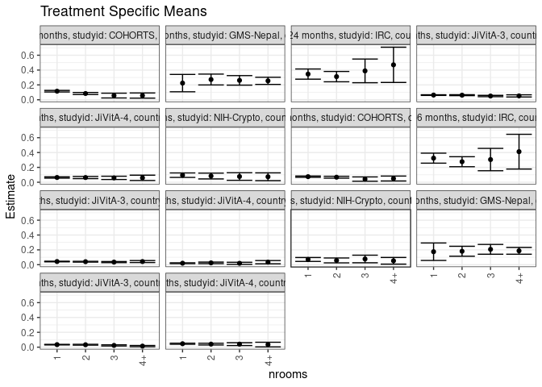

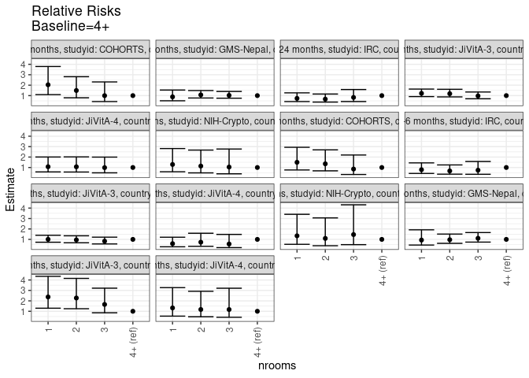

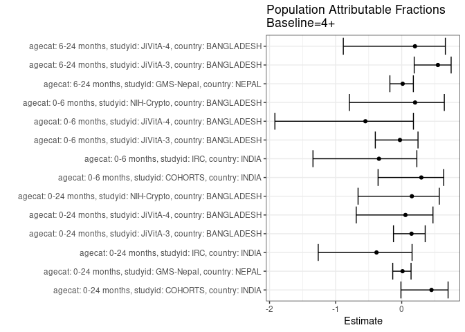

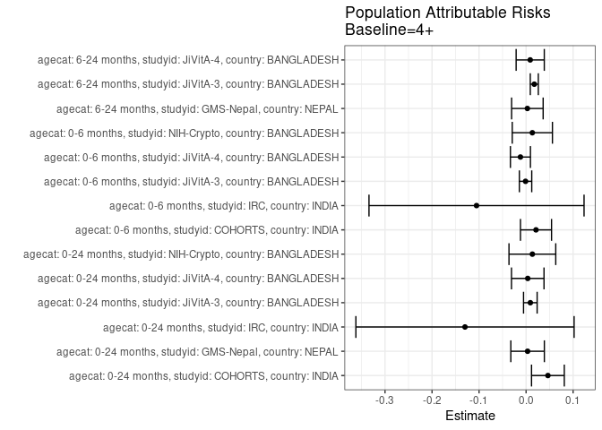

## Results Table

### Parameter: TSM

| agecat | studyid | country | intervention_level | baseline_level | estimate | ci_lower | ci_upper |
| --- | --- | --- | --- | --- | --- | --- | --- |
| 0-24 months | COHORTS | INDIA | 4+ | NA | 0.0566038 | 0.0218405 | 0.0913670 |
| 0-24 months | COHORTS | INDIA | 1 | NA | 0.1153518 | 0.1047843 | 0.1259192 |
| 0-24 months | COHORTS | INDIA | 2 | NA | 0.0842986 | 0.0704836 | 0.0981136 |
| 0-24 months | COHORTS | INDIA | 3 | NA | 0.0564103 | 0.0240254 | 0.0887951 |
| 0-24 months | GMS-Nepal | NEPAL | 4+ | NA | 0.2547771 | 0.2065464 | 0.3030077 |
| 0-24 months | GMS-Nepal | NEPAL | 1 | NA | 0.2244898 | 0.1075779 | 0.3414017 |
| 0-24 months | GMS-Nepal | NEPAL | 2 | NA | 0.2727273 | 0.1996790 | 0.3457755 |
| 0-24 months | GMS-Nepal | NEPAL | 3 | NA | 0.2611111 | 0.1968969 | 0.3253253 |
| 0-24 months | IRC | INDIA | 4+ | NA | 0.4705882 | 0.2330280 | 0.7081485 |
| 0-24 months | IRC | INDIA | 1 | NA | 0.3459459 | 0.2773172 | 0.4145747 |
| 0-24 months | IRC | INDIA | 2 | NA | 0.3117647 | 0.2420477 | 0.3814817 |
| 0-24 months | IRC | INDIA | 3 | NA | 0.3888889 | 0.2294469 | 0.5483308 |
| 0-24 months | JiVitA-3 | BANGLADESH | 4+ | NA | 0.0519824 | 0.0371775 | 0.0667873 |
| 0-24 months | JiVitA-3 | BANGLADESH | 1 | NA | 0.0631665 | 0.0586352 | 0.0676978 |
| 0-24 months | JiVitA-3 | BANGLADESH | 2 | NA | 0.0616552 | 0.0554152 | 0.0678951 |
| 0-24 months | JiVitA-3 | BANGLADESH | 3 | NA | 0.0504040 | 0.0414699 | 0.0593381 |
| 0-24 months | JiVitA-4 | BANGLADESH | 4+ | NA | 0.0594406 | 0.0238221 | 0.0950590 |
| 0-24 months | JiVitA-4 | BANGLADESH | 1 | NA | 0.0639098 | 0.0551960 | 0.0726235 |
| 0-24 months | JiVitA-4 | BANGLADESH | 2 | NA | 0.0634463 | 0.0487899 | 0.0781027 |
| 0-24 months | JiVitA-4 | BANGLADESH | 3 | NA | 0.0587189 | 0.0367070 | 0.0807307 |
| 0-24 months | NIH-Crypto | BANGLADESH | 4+ | NA | 0.0736842 | 0.0211140 | 0.1262544 |
| 0-24 months | NIH-Crypto | BANGLADESH | 1 | NA | 0.0951087 | 0.0651157 | 0.1251016 |
| 0-24 months | NIH-Crypto | BANGLADESH | 2 | NA | 0.0837696 | 0.0444541 | 0.1230851 |
| 0-24 months | NIH-Crypto | BANGLADESH | 3 | NA | 0.0769231 | 0.0256764 | 0.1281697 |
| 0-6 months | COHORTS | INDIA | 4+ | NA | 0.0500000 | 0.0168833 | 0.0831167 |
| 0-6 months | COHORTS | INDIA | 1 | NA | 0.0748964 | 0.0660190 | 0.0837738 |
| 0-6 months | COHORTS | INDIA | 2 | NA | 0.0676037 | 0.0548716 | 0.0803359 |
| 0-6 months | COHORTS | INDIA | 3 | NA | 0.0425532 | 0.0136973 | 0.0714091 |
| 0-6 months | IRC | INDIA | 4+ | NA | 0.4117647 | 0.1775271 | 0.6460023 |
| 0-6 months | IRC | INDIA | 1 | NA | 0.3243243 | 0.2567854 | 0.3918632 |
| 0-6 months | IRC | INDIA | 2 | NA | 0.2764706 | 0.2091560 | 0.3437852 |
| 0-6 months | IRC | INDIA | 3 | NA | 0.3055556 | 0.1548971 | 0.4562140 |
| 0-6 months | JiVitA-3 | BANGLADESH | 4+ | NA | 0.0425155 | 0.0290869 | 0.0559441 |
| 0-6 months | JiVitA-3 | BANGLADESH | 1 | NA | 0.0427727 | 0.0388288 | 0.0467165 |
| 0-6 months | JiVitA-3 | BANGLADESH | 2 | NA | 0.0404656 | 0.0352418 | 0.0456895 |
| 0-6 months | JiVitA-3 | BANGLADESH | 3 | NA | 0.0351895 | 0.0274011 | 0.0429779 |
| 0-6 months | JiVitA-4 | BANGLADESH | 4+ | NA | 0.0338346 | 0.0120568 | 0.0556124 |
| 0-6 months | JiVitA-4 | BANGLADESH | 1 | NA | 0.0200468 | 0.0144869 | 0.0256066 |
| 0-6 months | JiVitA-4 | BANGLADESH | 2 | NA | 0.0247295 | 0.0143388 | 0.0351202 |
| 0-6 months | JiVitA-4 | BANGLADESH | 3 | NA | 0.0188679 | 0.0052062 | 0.0325296 |
| 0-6 months | NIH-Crypto | BANGLADESH | 4+ | NA | 0.0526316 | 0.0076996 | 0.0975636 |
| 0-6 months | NIH-Crypto | BANGLADESH | 1 | NA | 0.0706522 | 0.0444545 | 0.0968498 |
| 0-6 months | NIH-Crypto | BANGLADESH | 2 | NA | 0.0575916 | 0.0245305 | 0.0906527 |
| 0-6 months | NIH-Crypto | BANGLADESH | 3 | NA | 0.0769231 | 0.0256764 | 0.1281697 |
| 6-24 months | GMS-Nepal | NEPAL | 4+ | NA | 0.1870504 | 0.1411723 | 0.2329284 |
| 6-24 months | GMS-Nepal | NEPAL | 1 | NA | 0.1750000 | 0.0571492 | 0.2928508 |
| 6-24 months | GMS-Nepal | NEPAL | 2 | NA | 0.1811024 | 0.1140689 | 0.2481358 |
| 6-24 months | GMS-Nepal | NEPAL | 3 | NA | 0.2068966 | 0.1409072 | 0.2728859 |
| 6-24 months | JiVitA-3 | BANGLADESH | 4+ | NA | 0.0144357 | 0.0058662 | 0.0230051 |
| 6-24 months | JiVitA-3 | BANGLADESH | 1 | NA | 0.0342701 | 0.0304062 | 0.0381340 |
| 6-24 months | JiVitA-3 | BANGLADESH | 2 | NA | 0.0328138 | 0.0271387 | 0.0384889 |
| 6-24 months | JiVitA-3 | BANGLADESH | 3 | NA | 0.0239180 | 0.0163962 | 0.0314398 |
| 6-24 months | JiVitA-4 | BANGLADESH | 4+ | NA | 0.0350877 | 0.0040322 | 0.0661433 |
| 6-24 months | JiVitA-4 | BANGLADESH | 1 | NA | 0.0463804 | 0.0388821 | 0.0538788 |
| 6-24 months | JiVitA-4 | BANGLADESH | 2 | NA | 0.0411255 | 0.0291154 | 0.0531357 |
| 6-24 months | JiVitA-4 | BANGLADESH | 3 | NA | 0.0409982 | 0.0218843 | 0.0601121 |

### Parameter: E(Y)

| agecat | studyid | country | intervention_level | baseline_level | estimate | ci_lower | ci_upper |
| --- | --- | --- | --- | --- | --- | --- | --- |
| 0-24 months | COHORTS | INDIA | NA | NA | 0.1030563 | 0.0949208 | 0.1111918 |
| 0-24 months | GMS-Nepal | NEPAL | NA | NA | 0.2580175 | 0.2252514 | 0.2907836 |
| 0-24 months | IRC | INDIA | NA | NA | 0.3406863 | 0.2946421 | 0.3867304 |
| 0-24 months | JiVitA-3 | BANGLADESH | NA | NA | 0.0610562 | 0.0575753 | 0.0645372 |
| 0-24 months | JiVitA-4 | BANGLADESH | NA | NA | 0.0630182 | 0.0560941 | 0.0699424 |
| 0-24 months | NIH-Crypto | BANGLADESH | NA | NA | 0.0870712 | 0.0669870 | 0.1071555 |
| 0-6 months | COHORTS | INDIA | NA | NA | 0.0711240 | 0.0641102 | 0.0781378 |
| 0-6 months | IRC | INDIA | NA | NA | 0.3063725 | 0.2615869 | 0.3511582 |
| 0-6 months | JiVitA-3 | BANGLADESH | NA | NA | 0.0414104 | 0.0384280 | 0.0443929 |
| 0-6 months | JiVitA-4 | BANGLADESH | NA | NA | 0.0218375 | 0.0173809 | 0.0262941 |
| 0-6 months | NIH-Crypto | BANGLADESH | NA | NA | 0.0659631 | 0.0482810 | 0.0836451 |
| 6-24 months | GMS-Nepal | NEPAL | NA | NA | 0.1898305 | 0.1581595 | 0.2215015 |
| 6-24 months | JiVitA-3 | BANGLADESH | NA | NA | 0.0319334 | 0.0290403 | 0.0348264 |
| 6-24 months | JiVitA-4 | BANGLADESH | NA | NA | 0.0438871 | 0.0380629 | 0.0497114 |

### Parameter: RR

| agecat | studyid | country | intervention_level | baseline_level | estimate | ci_lower | ci_upper |
| --- | --- | --- | --- | --- | --- | --- | --- |
| 0-24 months | COHORTS | INDIA | 4+ | 4+ | 1.0000000 | 1.0000000 | 1.000000 |
| 0-24 months | COHORTS | INDIA | 1 | 4+ | 2.0378809 | 1.0952301 | 3.791860 |
| 0-24 months | COHORTS | INDIA | 2 | 4+ | 1.4892750 | 0.7887145 | 2.812095 |
| 0-24 months | COHORTS | INDIA | 3 | 4+ | 0.9965812 | 0.4299360 | 2.310051 |
| 0-24 months | GMS-Nepal | NEPAL | 4+ | 4+ | 1.0000000 | 1.0000000 | 1.000000 |
| 0-24 months | GMS-Nepal | NEPAL | 1 | 4+ | 0.8811224 | 0.5062690 | 1.533526 |
| 0-24 months | GMS-Nepal | NEPAL | 2 | 4+ | 1.0704545 | 0.7711244 | 1.485977 |
| 0-24 months | GMS-Nepal | NEPAL | 3 | 4+ | 1.0248611 | 0.7514191 | 1.397809 |
| 0-24 months | IRC | INDIA | 4+ | 4+ | 1.0000000 | 1.0000000 | 1.000000 |
| 0-24 months | IRC | INDIA | 1 | 4+ | 0.7351351 | 0.4273735 | 1.264523 |
| 0-24 months | IRC | INDIA | 2 | 4+ | 0.6625000 | 0.3814169 | 1.150726 |
| 0-24 months | IRC | INDIA | 3 | 4+ | 0.8263889 | 0.4312690 | 1.583509 |
| 0-24 months | JiVitA-3 | BANGLADESH | 4+ | 4+ | 1.0000000 | 1.0000000 | 1.000000 |
| 0-24 months | JiVitA-3 | BANGLADESH | 1 | 4+ | 1.2151517 | 0.9082898 | 1.625686 |
| 0-24 months | JiVitA-3 | BANGLADESH | 2 | 4+ | 1.1860783 | 0.8758072 | 1.606269 |
| 0-24 months | JiVitA-3 | BANGLADESH | 3 | 4+ | 0.9696363 | 0.6991369 | 1.344793 |
| 0-24 months | JiVitA-4 | BANGLADESH | 4+ | 4+ | 1.0000000 | 1.0000000 | 1.000000 |
| 0-24 months | JiVitA-4 | BANGLADESH | 1 | 4+ | 1.0751880 | 0.5766593 | 2.004701 |
| 0-24 months | JiVitA-4 | BANGLADESH | 2 | 4+ | 1.0673905 | 0.5654622 | 2.014852 |
| 0-24 months | JiVitA-4 | BANGLADESH | 3 | 4+ | 0.9878585 | 0.4888192 | 1.996371 |
| 0-24 months | NIH-Crypto | BANGLADESH | 4+ | 4+ | 1.0000000 | 1.0000000 | 1.000000 |
| 0-24 months | NIH-Crypto | BANGLADESH | 1 | 4+ | 1.2907609 | 0.5916685 | 2.815873 |
| 0-24 months | NIH-Crypto | BANGLADESH | 2 | 4+ | 1.1368736 | 0.4839859 | 2.670494 |
| 0-24 months | NIH-Crypto | BANGLADESH | 3 | 4+ | 1.0439560 | 0.3933243 | 2.770854 |
| 0-6 months | COHORTS | INDIA | 4+ | 4+ | 1.0000000 | 1.0000000 | 1.000000 |
| 0-6 months | COHORTS | INDIA | 1 | 4+ | 1.4979278 | 0.7643161 | 2.935680 |
| 0-6 months | COHORTS | INDIA | 2 | 4+ | 1.3520750 | 0.6791251 | 2.691855 |
| 0-6 months | COHORTS | INDIA | 3 | 4+ | 0.8510638 | 0.3298314 | 2.196000 |
| 0-6 months | IRC | INDIA | 4+ | 4+ | 1.0000000 | 1.0000000 | 1.000000 |
| 0-6 months | IRC | INDIA | 1 | 4+ | 0.7876448 | 0.4297768 | 1.443503 |
| 0-6 months | IRC | INDIA | 2 | 4+ | 0.6714286 | 0.3616328 | 1.246613 |
| 0-6 months | IRC | INDIA | 3 | 4+ | 0.7420635 | 0.3495437 | 1.575363 |
| 0-6 months | JiVitA-3 | BANGLADESH | 4+ | 4+ | 1.0000000 | 1.0000000 | 1.000000 |
| 0-6 months | JiVitA-3 | BANGLADESH | 1 | 4+ | 1.0060490 | 0.7261691 | 1.393800 |
| 0-6 months | JiVitA-3 | BANGLADESH | 2 | 4+ | 0.9517854 | 0.6729443 | 1.346167 |
| 0-6 months | JiVitA-3 | BANGLADESH | 3 | 4+ | 0.8276859 | 0.5642192 | 1.214181 |
| 0-6 months | JiVitA-4 | BANGLADESH | 4+ | 4+ | 1.0000000 | 1.0000000 | 1.000000 |
| 0-6 months | JiVitA-4 | BANGLADESH | 1 | 4+ | 0.5924936 | 0.2909712 | 1.206472 |
| 0-6 months | JiVitA-4 | BANGLADESH | 2 | 4+ | 0.7308947 | 0.3365753 | 1.587184 |
| 0-6 months | JiVitA-4 | BANGLADESH | 3 | 4+ | 0.5576520 | 0.2104715 | 1.477520 |
| 0-6 months | NIH-Crypto | BANGLADESH | 4+ | 4+ | 1.0000000 | 1.0000000 | 1.000000 |
| 0-6 months | NIH-Crypto | BANGLADESH | 1 | 4+ | 1.3423913 | 0.5292449 | 3.404878 |
| 0-6 months | NIH-Crypto | BANGLADESH | 2 | 4+ | 1.0942408 | 0.3911333 | 3.061266 |
| 0-6 months | NIH-Crypto | BANGLADESH | 3 | 4+ | 1.4615385 | 0.4949003 | 4.316212 |
| 6-24 months | GMS-Nepal | NEPAL | 4+ | 4+ | 1.0000000 | 1.0000000 | 1.000000 |
| 6-24 months | GMS-Nepal | NEPAL | 1 | 4+ | 0.9355769 | 0.4568959 | 1.915763 |
| 6-24 months | GMS-Nepal | NEPAL | 2 | 4+ | 0.9682011 | 0.6210490 | 1.509403 |
| 6-24 months | GMS-Nepal | NEPAL | 3 | 4+ | 1.1061008 | 0.7397006 | 1.653992 |
| 6-24 months | JiVitA-3 | BANGLADESH | 4+ | 4+ | 1.0000000 | 1.0000000 | 1.000000 |
| 6-24 months | JiVitA-3 | BANGLADESH | 1 | 4+ | 2.3739845 | 1.2959262 | 4.348860 |
| 6-24 months | JiVitA-3 | BANGLADESH | 2 | 4+ | 2.2731002 | 1.2437737 | 4.154280 |
| 6-24 months | JiVitA-3 | BANGLADESH | 3 | 4+ | 1.6568648 | 0.8541114 | 3.214102 |
| 6-24 months | JiVitA-4 | BANGLADESH | 4+ | 4+ | 1.0000000 | 1.0000000 | 1.000000 |
| 6-24 months | JiVitA-4 | BANGLADESH | 1 | 4+ | 1.3218427 | 0.5346662 | 3.267961 |
| 6-24 months | JiVitA-4 | BANGLADESH | 2 | 4+ | 1.1720779 | 0.4710585 | 2.916339 |
| 6-24 months | JiVitA-4 | BANGLADESH | 3 | 4+ | 1.1684492 | 0.4253653 | 3.209649 |

### Parameter: PAR

| agecat | studyid | country | intervention_level | baseline_level | estimate | ci_lower | ci_upper |
| --- | --- | --- | --- | --- | --- | --- | --- |
| 0-24 months | COHORTS | INDIA | 4+ | NA | 0.0464525 | 0.0116065 | 0.0812985 |
| 0-24 months | GMS-Nepal | NEPAL | 4+ | NA | 0.0032404 | -0.0324007 | 0.0388816 |
| 0-24 months | IRC | INDIA | 4+ | NA | -0.1299020 | -0.3619624 | 0.1021585 |
| 0-24 months | JiVitA-3 | BANGLADESH | 4+ | NA | 0.0090738 | -0.0053877 | 0.0235354 |
| 0-24 months | JiVitA-4 | BANGLADESH | 4+ | NA | 0.0035777 | -0.0310081 | 0.0381635 |
| 0-24 months | NIH-Crypto | BANGLADESH | 4+ | NA | 0.0133870 | -0.0363551 | 0.0631291 |
| 0-6 months | COHORTS | INDIA | 4+ | NA | 0.0211240 | -0.0119074 | 0.0541554 |
| 0-6 months | IRC | INDIA | 4+ | NA | -0.1053922 | -0.3340857 | 0.1233014 |
| 0-6 months | JiVitA-3 | BANGLADESH | 4+ | NA | -0.0011051 | -0.0142715 | 0.0120613 |
| 0-6 months | JiVitA-4 | BANGLADESH | 4+ | NA | -0.0119971 | -0.0332960 | 0.0093018 |
| 0-6 months | NIH-Crypto | BANGLADESH | 4+ | NA | 0.0133315 | -0.0293942 | 0.0560572 |
| 6-24 months | GMS-Nepal | NEPAL | 4+ | NA | 0.0027801 | -0.0307511 | 0.0363114 |
| 6-24 months | JiVitA-3 | BANGLADESH | 4+ | NA | 0.0174977 | 0.0089640 | 0.0260313 |
| 6-24 months | JiVitA-4 | BANGLADESH | 4+ | NA | 0.0087994 | -0.0211326 | 0.0387315 |

### Parameter: PAF

| agecat | studyid | country | intervention_level | baseline_level | estimate | ci_lower | ci_upper |
| --- | --- | --- | --- | --- | --- | --- | --- |
| 0-24 months | COHORTS | INDIA | 4+ | NA | 0.4507489 | -0.0116500 | 0.7017973 |
| 0-24 months | GMS-Nepal | NEPAL | 4+ | NA | 0.0125589 | -0.1357010 | 0.1414643 |
| 0-24 months | IRC | INDIA | 4+ | NA | -0.3812950 | -1.2631390 | 0.1569339 |
| 0-24 months | JiVitA-3 | BANGLADESH | 4+ | NA | 0.1486146 | -0.1244381 | 0.3553607 |
| 0-24 months | JiVitA-4 | BANGLADESH | 4+ | NA | 0.0567722 | -0.6884058 | 0.4730658 |
| 0-24 months | NIH-Crypto | BANGLADESH | 4+ | NA | 0.1537480 | -0.6603715 | 0.5686854 |
| 0-6 months | COHORTS | INDIA | 4+ | NA | 0.2970027 | -0.3574646 | 0.6359351 |
| 0-6 months | IRC | INDIA | 4+ | NA | -0.3440000 | -1.3426548 | 0.2289363 |
| 0-6 months | JiVitA-3 | BANGLADESH | 4+ | NA | -0.0266862 | -0.3994398 | 0.2467811 |
| 0-6 months | JiVitA-4 | BANGLADESH | 4+ | NA | -0.5493802 | -1.9189114 | 0.1775773 |
| 0-6 months | NIH-Crypto | BANGLADESH | 4+ | NA | 0.2021053 | -0.7922758 | 0.6447890 |
| 6-24 months | GMS-Nepal | NEPAL | 4+ | NA | 0.0146454 | -0.1788038 | 0.1763484 |
| 6-24 months | JiVitA-3 | BANGLADESH | 4+ | NA | 0.5479431 | 0.1893305 | 0.7479176 |
| 6-24 months | JiVitA-4 | BANGLADESH | 4+ | NA | 0.2005013 | -0.8836952 | 0.6606679 |